# Alzheimer’s Detection Using Handwriting Analysis

## Residual Analysis

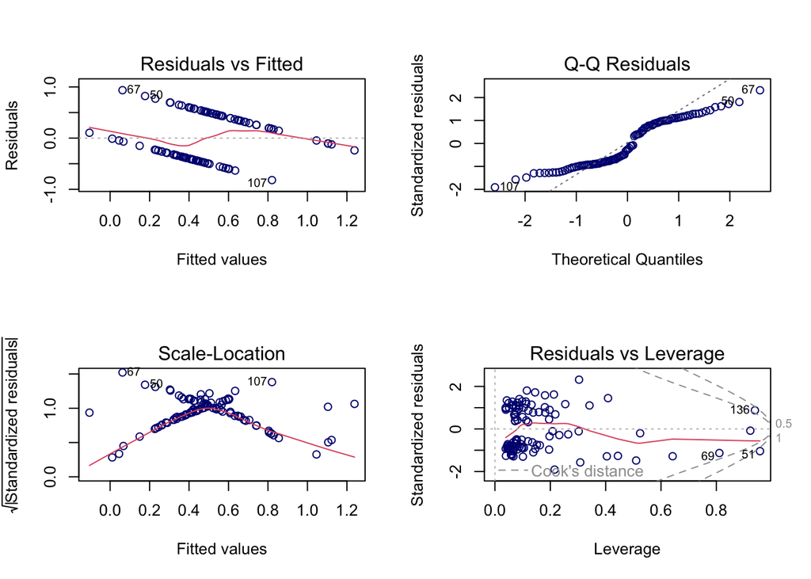

```r
# Visualizing the linear regression residuals
par(mfrow=c(2,2))
plot(lm_model_selected, col = "navy")
```

The residuals vs leverage plot indicates the existence of outliers that are skewing the data and masking the true distribution of each feature. The high leverage outliers fortunately lie close to the zero line, suggesting that they are not significantly impacting the model’s performance but moderately powerful features around the 0.2 leverage mark lie far from the zero lie, indicating that these features are skewing the data. The Q-Q Residuals fit is shaped like a moderate S, indicating that the residuals are not normally distributed. The scale-location plot shows that the residuals are not homoscedastic, which is another violation of the assumptions of linear regression. These results suggest that the model is not a great fit for the data and that further investigation is needed to improve the model’s performance. These residuals give us lots of insight into model performance that extend far beyond the raw accuracy of the model.

## Random Forest Model

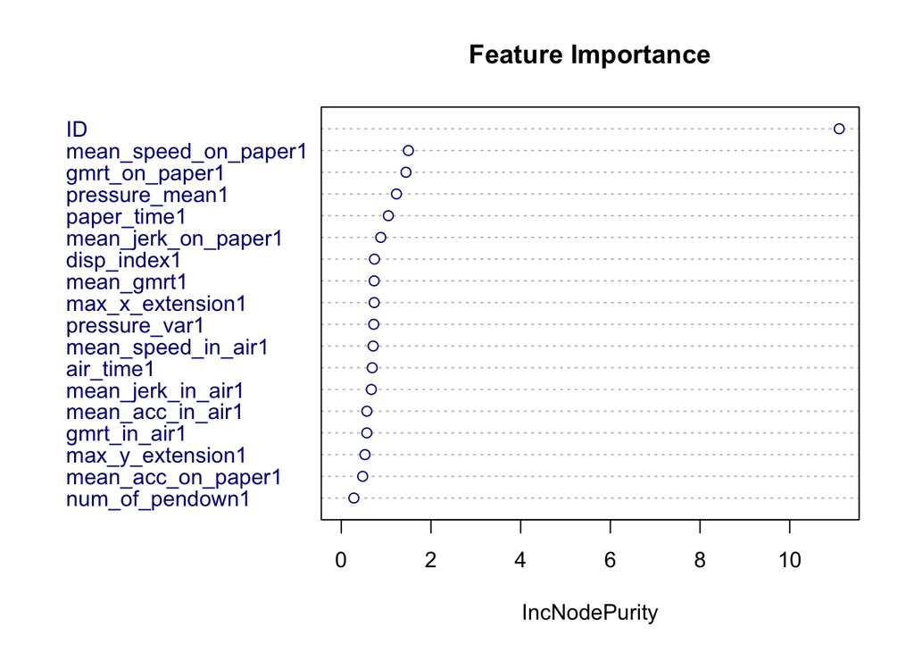